# Was unsere Stimmzettel über die politische Landschaft Bremens verraten

**Jan Lorenz**

Open Campus Day

19. September 2026

## Politische Landschaften

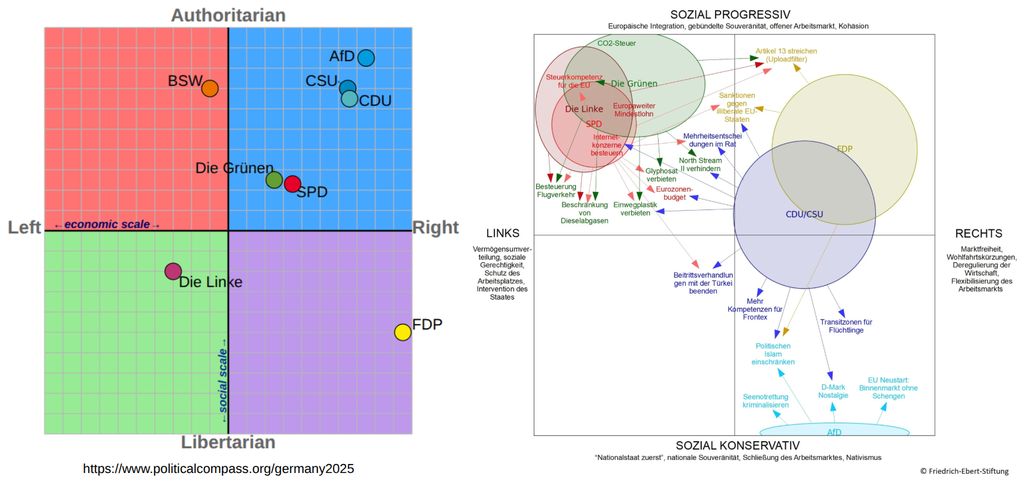

In diesen Beispielen werden die Dimensionen weitgehend konzeptionell definiert und durch Fragebögen oder Experten-Einschätzung erhoben.

## Politische Landschaften in Bremen

Bestimmung der Dimensionen aus Texten der Wahlprogramme mit der `wordscores` Methods.

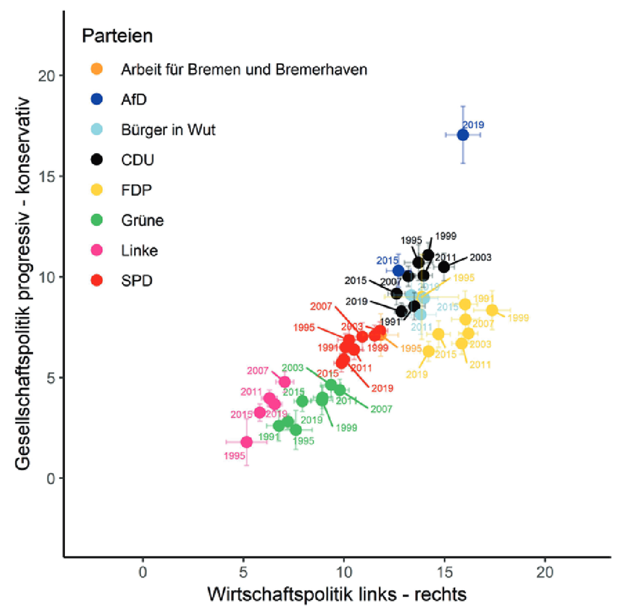

Bräuninger, T., Debus, M., Müller, J., & Stecker, C. (2020). [Parteienwettbewerb in den deutschen Bundesländern.](https://doi.org/10.1007/978-3-658-29222-5) Springer Fachmedien.

## Wahlen zur Bremischen Bürgerschaft

- Zwei Wahlgebiete
  - **Bremen** (Stadt) **72** Abgeordnete
  - **Bremerhaven** **15** Abgeordnete
- Technisch unabhängige Wahlen: Eigene Listen, eigene 5% Sperrklausel

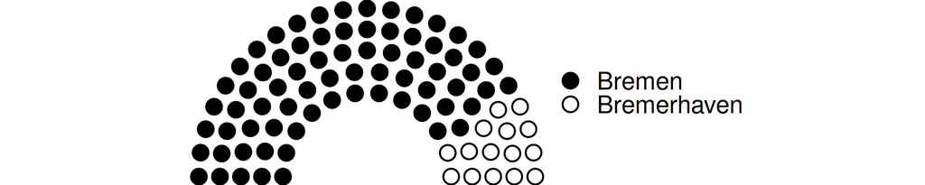

## Wählen: 5 Stimmen aufteilen

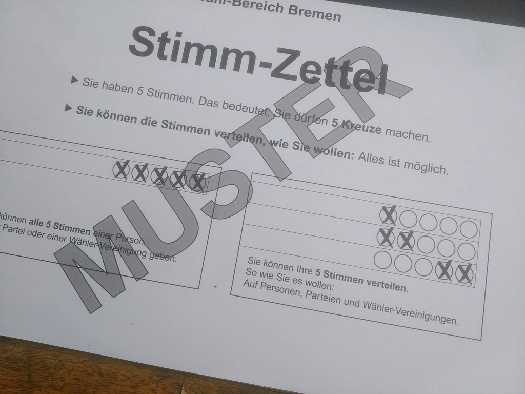

## Listenstimmen und Personenstimmen

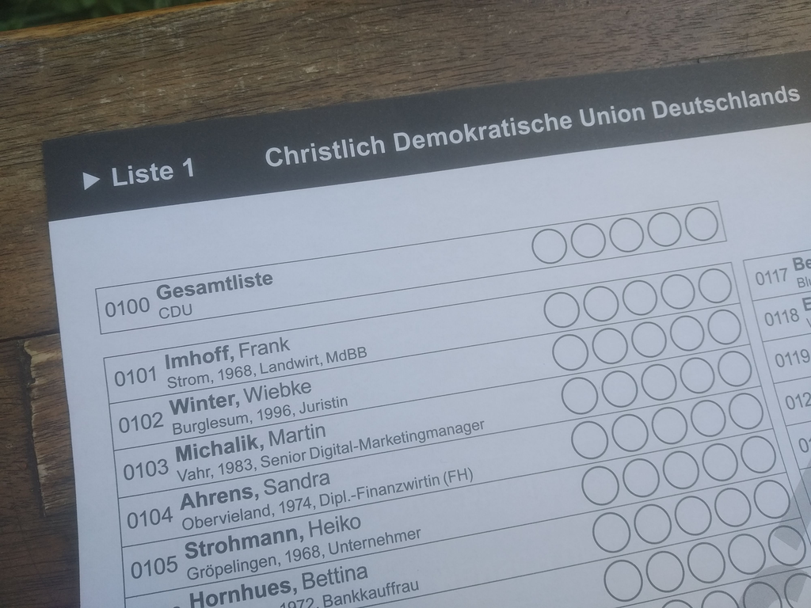

## Digitale Stimmzettel Erfassung

Beispiele Stimmzettel 2023

| Stimme1 | Stimme2 | Stimme3 | Stimme4 | Stimme5 | n |
| --- | --- | --- | --- | --- | --- |
| 100 | 100 | 100 | 100 | 100 | 25755 |
| 201 | 201 | 201 | 201 | 201 | 13382 |
| 200 | 200 | 200 | 200 | 200 | 13309 |
| 600 | 600 | 600 | 600 | 600 | 9891 |
| 237 | 237 | 237 | 237 | 237 | 514 |
| 314 | 314 | 314 | 314 | 314 | 416 |
| 100 | 100 | 600 | 600 | 600 | 190 |
| 300 | 300 | 1600 | 1600 | 1600 | 163 |
| 201 | 201 | 600 | 600 | 600 | 88 |
| 201 | 1600 | 1600 | 1600 | 1600 | 40 |
| 101 | 201 | 203 | 401 | 402 | 38 |
| 100 | 100 | 100 | 200 | 300 | 35 |
| 101 | 101 | 101 | 401 | 402 | 34 |
| 201 | 203 | 401 | 401 | 402 | 34 |
| 500 | 500 | 1600 | 1600 | 1600 | 28 |

Die Stimmzettel-Daten werden vom statistischen Landesamt nur zur Verfügung gestellt, wenn das Wahlgeheimnis durch die Forscher nicht gefährdet wird. (Vertragsstrafen)

## Viele Stimmzettel sind einzigartig

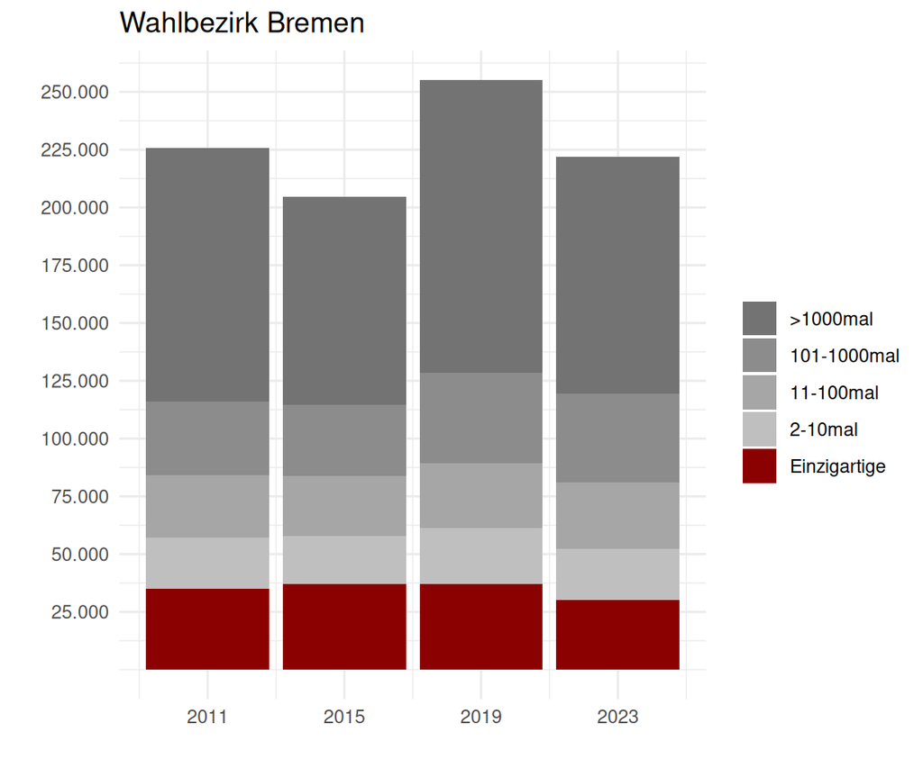

## Vereinfachung: Personenstimmen als Parteistimmen

1XX -> 100, 2XX -> 200, … Die 50 häufigsten Parteimuster.

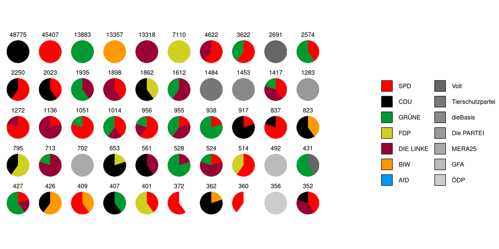

Ein Tortenstück steht für eine Stimme für die Liste oder eine kandidierende Person der Partei.

## Ähnlichkeit von Parteien durch gemeinsame Wähler

| X | Y | Gemeinsame Wähler | X-Wähler wählen Y | Y-Wähler wählen X |
| --- | --- | --- | --- | --- |
| CDU | SPD | 11470 | 16.10% | 12.76% |
| CDU | GRÜNE | 3234 | 4.54% | 7.62% |
| CDU | DIE LINKE | 3618 | 5.08% | 8.48% |
| CDU | FDP | 5946 | 8.35% | 34.33% |
| CDU | BIW | 3198 | 4.49% | 15.70% |

| X | Y | Gemeinsame Wähler | X-Wähler wählen Y | Y-Wähler wählen X |
| --- | --- | --- | --- | --- |
| SPD | GRÜNE | 18011 | 20.04% | 42.45% |
| SPD | DIE LINKE | 18559 | 20.65% | 43.52% |
| SPD | FDP | 3629 | 4.04% | 20.95% |
| SPD | BIW | 2242 | 2.49% | 11.01% |

| X | Y | Gemeinsame Wähler | X-Wähler wählen Y | Y-Wähler wählen X |
| --- | --- | --- | --- | --- |
| GRÜNE | DIE LINKE | 12793 | 30.15% | 30.00% |
| GRÜNE | FDP | 1288 | 3.04% | 7.44% |
| GRÜNE | BIW | 253 | 0.60% | 1.24% |

| X | Y | Gemeinsame Wähler | X-Wähler wählen Y | Y-Wähler wählen X |
| --- | --- | --- | --- | --- |
| DIE LINKE | FDP | 1076 | 2.52% | 6.21% |
| DIE LINKE | BIW | 782 | 1.83% | 3.84% |

## Politischer Raum 2023

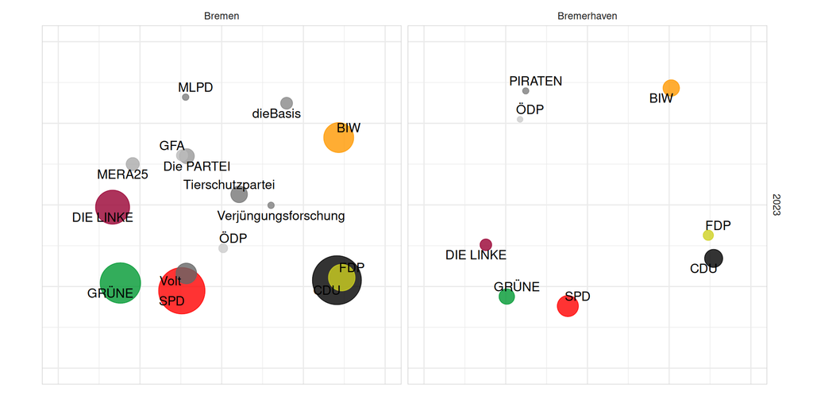

Die Positionen wurden mit multidimensionaler Skalierung berechnet. Zugrunde liegen als Distanzmatrix die paarweisen symmetrischen Wahrscheinlichkeiten, dass ein Wähler aus einer der beiden Parteien nicht die andere Partei wählt. Die Methode erzeugt Positionen die diese Distanzen bestmöglich im 2-dimensionalen Raum abbilden.

## Politischer Raum 2019

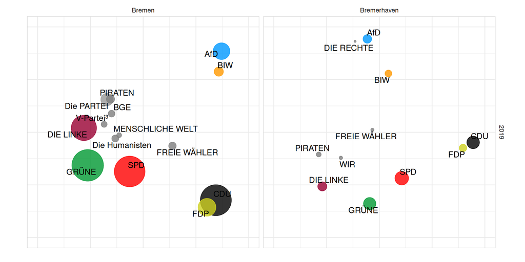

Die Positionen wurden multidimensionaler Skalierung berechnet. Zugrunde liegen als Distanzmatrix die paarweisen symmetrischen Wahrscheinlichkeiten, dass ein Wähler aus einer der beiden Parteien nicht die andere Partei wählt. Die Methode erzeugt Positionen die diese Distanzen bestmöglich im 2-dimensionalen Raum abbilden.

## Politischer Raum 2015

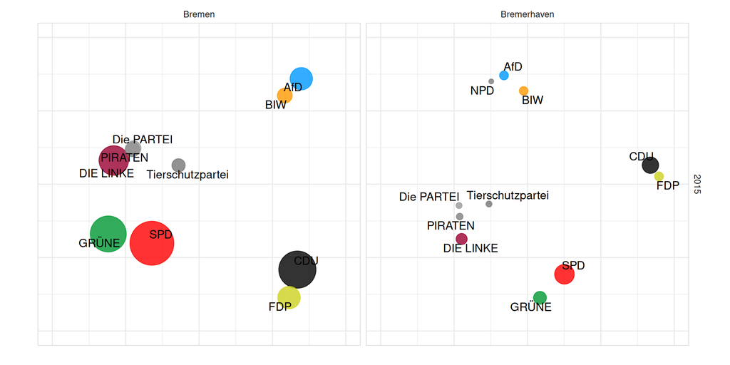

Die Positionen wurden multidimensionaler Skalierung berechnet. Zugrunde liegen als Distanzmatrix die paarweisen symmetrischen Wahrscheinlichkeiten, dass ein Wähler aus einer der beiden Parteien nicht die andere Partei wählt. Die Methode erzeugt Positionen die diese Distanzen bestmöglich im 2-dimensionalen Raum abbilden.

## Politischer Raum 2011

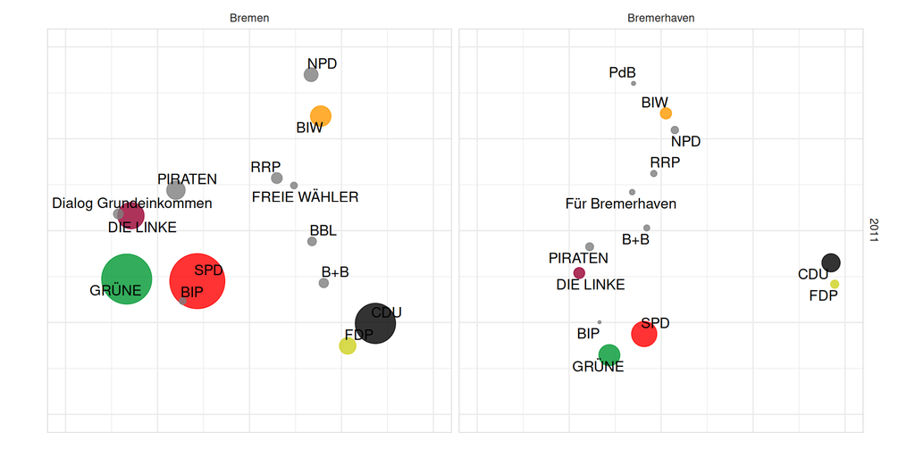

Die Positionen wurden multidimensionaler Skalierung berechnet. Zugrunde liegen als Distanzmatrix die paarweisen symmetrischen Wahrscheinlichkeiten, dass ein Wähler aus einer der beiden Parteien nicht die andere Partei wählt. Die Methode erzeugt Positionen die diese Distanzen bestmöglich im 2-dimensionalen Raum abbilden.

## Politischer Raum

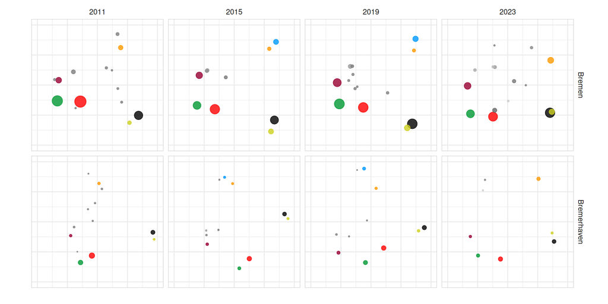

## Gemeinsame Wähler vs. Wahlprogramm-Texte

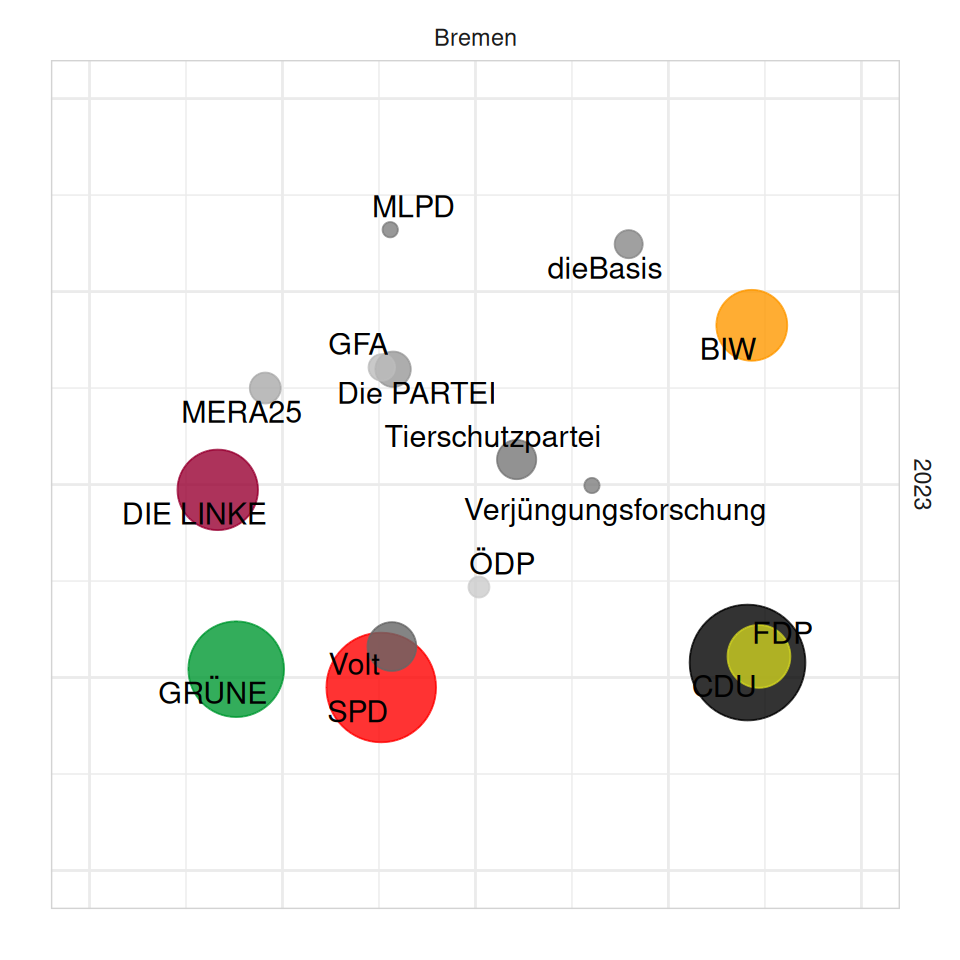

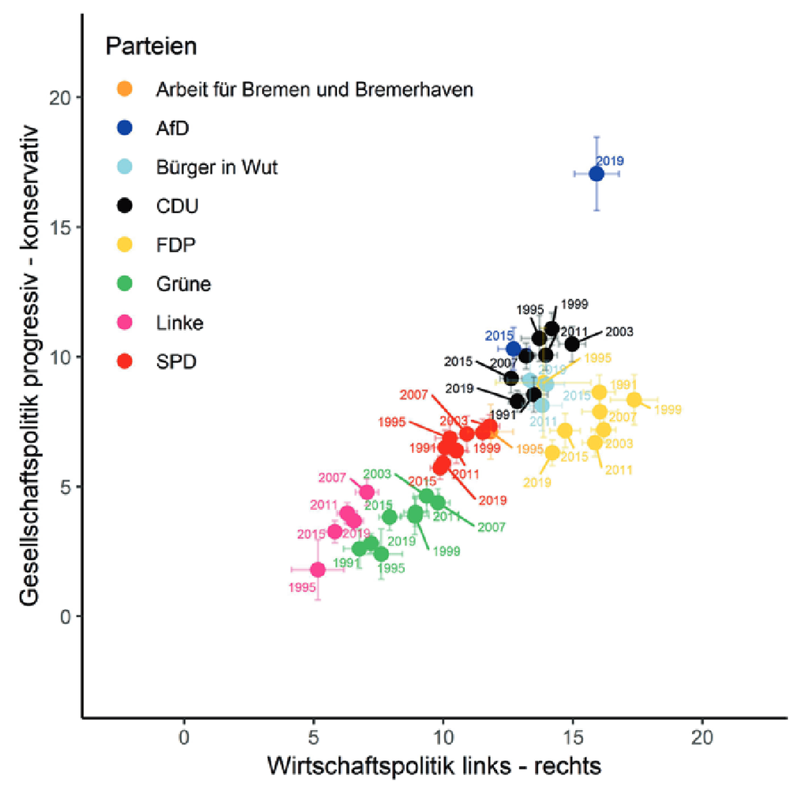

## Hufeisen-Schema?

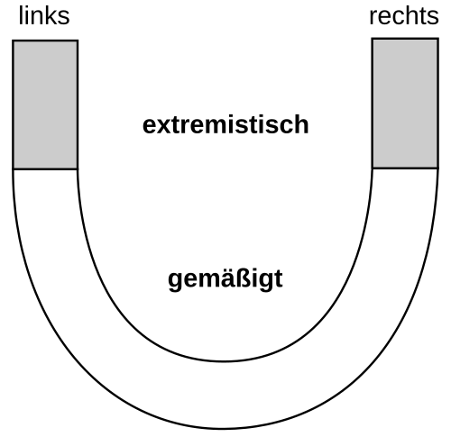

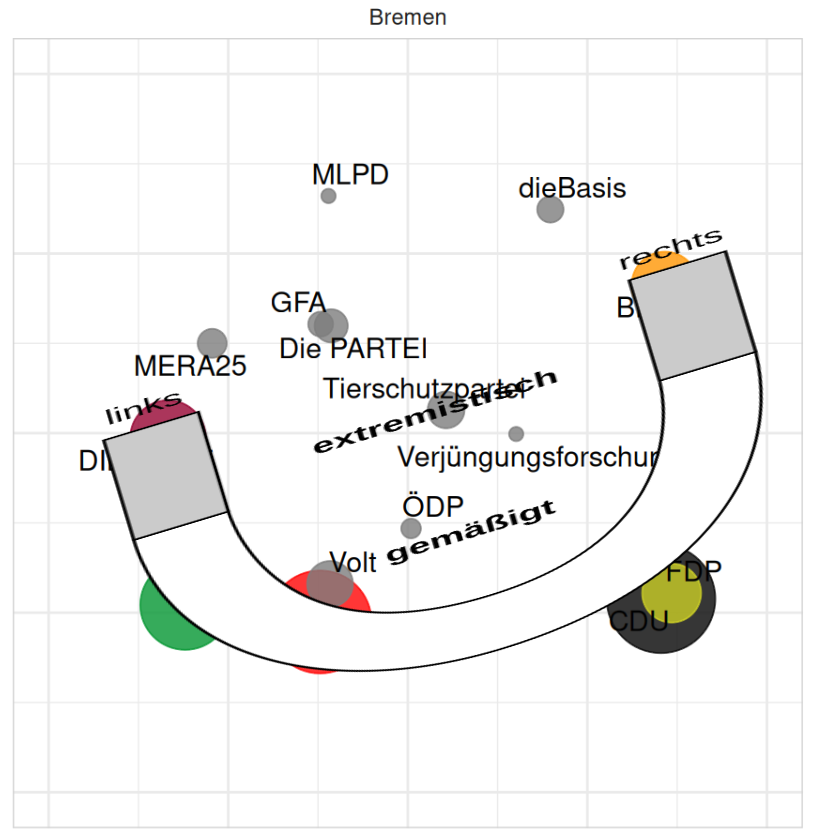

## Zusammenfassung

**Was interessiert Sie als Wähler? Kontaktieren Sie mich gerne!**

# Appendix

## Häufigste Stimmzettelmuster 2019

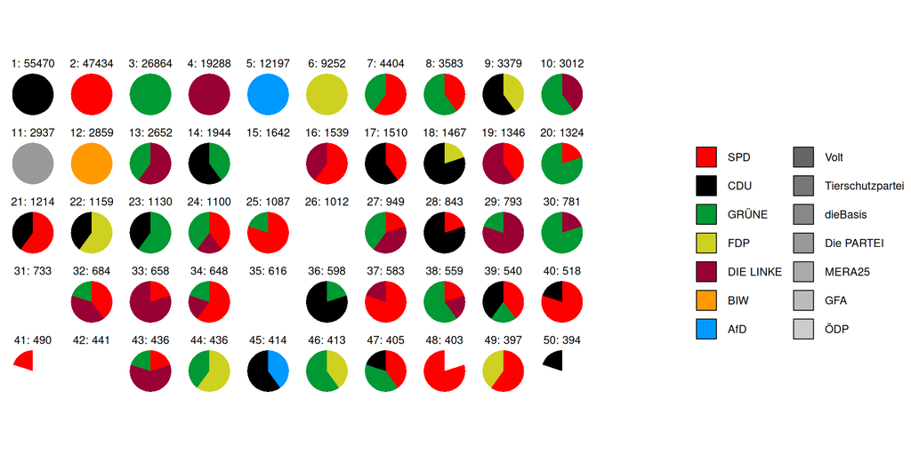

## Wahl-O-Mat 2023 MDS

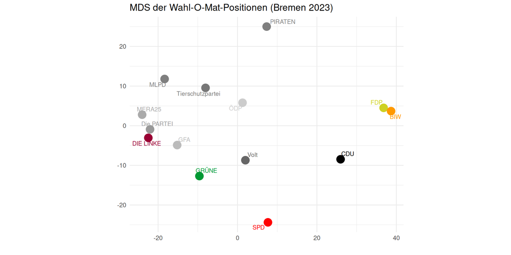